# Rigdon_Jack_Hw_TopicModeling

All laboratory assignments and homework will be evaluated based on three key criteria:

1. **Accuracy of Python Code**: Your Python code submissions must be precise and correct.
2. **Clarity and Organization of Jupyter Notebook**:
- Ensure that your Jupyter notebook is well-structured and neatly organized.
- Each Python code snippet should be supplemented with appropriate comments using either the "#" symbol or Markdown text.
1. **Effective Presentation of Outputs**: Within your Jupyter notebook, make sure all outputs are clearly visible. If necessary, provide explanations for these outputs using Markdown annotations. However, **avoid displaying entire output blocks; instead, display only the initial two to five rows for clarity**.

Additionally, all submissions must adhere to the following formatting requirements:

- Inclusion of K-State Honor Code: Each laboratory assignment and homework must contain the K-State Honor Code statement: `"On my honor, as a student, I have neither given nor received unauthorized aid on this academic work."`
- Academic Honesty and Consequences: Breach of academic honesty can result in a grade of XF, where "F" indicates failure in the course, and "X" indicates an Honor Pledge violation. Detailed information can be found at this link: http://www.k-state.edu/provost/resources/teaching/course.htm

It's important to note the following prohibitions:

- **Unauthorized Collaboration**: Collaborating with other students on laboratory assignments, homework, the midterm exam, or the final project is strictly prohibited.
- **Unauthorized Aid**: Sharing your code with other students or receiving code from others is considered unauthorized aid and is not allowed.
- **Plagiarism**: Presenting the words of another individual (whether from the Internet or articles) as your own is considered plagiarism and is not permitted.

Adherence to these guidelines will ensure a fair and respectful learning environment and help maintain academic integrity.

**K-State Honor Code**

**Your Name:** Jack C. Rigdon

## Section 1: Data Preperation

```python
# import packages for text processing
import nltk
from nltk.corpus import stopwords
from nltk.stem.wordnet import WordNetLemmatizer
from nltk.stem.porter import PorterStemmer
import re

# gensim for topic modeling
import gensim
from gensim.corpora import Dictionary
from gensim.models import LdaModel, CoherenceModel
from gensim import corpora, models, similarities
from gensim.models.coherencemodel import CoherenceModel

import csv
import pandas as pd
import numpy
import matplotlib.pyplot as plt
%matplotlib inline

from gensim import corpora
from nltk.corpus import stopwords
from nltk.tokenize import word_tokenize
import nltk
nltk.download('stopwords')
nltk.download('punkt')

# show images
from IPython.display import Image
from IPython.core.display import HTML

# suppress error messages
import warnings
warnings.filterwarnings('ignore')  # To ignore all warnings that arise here to enhance clarity
```

```python
data = []
with open('data/hw_topicmodeling.csv', 'r', encoding='utf-8') as file:
    r = csv.reader(file)
    for i in r:
        data.append(i)

len(data)

file_path = 'data/hw_topicmodeling.csv'

# Read the CSV file into a DataFrame
df = pd.read_csv(file_path, encoding='utf-8')

# Show the first few rows of the DataFrame
print(df.head(2))

text_column = df['text']

# Show the first few rows of the 'text' column
print(text_column.head())

data = df['text'].values.tolist()
print(data[:1])
```

```
                                       uuid  ord_in_thread  \
0  6a175f46bcd24d39b3e962ad0f29936721db70db              0
1  2bdc29d12605ef9cf3f09f9875040a7113be5d5b              0

                 author                      published  \
0     Barracuda Brigade  2016-10-26T21:41:00.000+03:00
1  reasoning with facts  2016-10-29T08:47:11.259+03:00

                                               title  \
0  Muslims BUSTED: They Stole Millions In Gov’t B...
1  Re: Why Did Attorney General Loretta Lynch Ple...

                                                text language  \
0  Print They should pay all the back all the mon...  english
1  Why Did Attorney General Loretta Lynch Plead T...  english

                         crawled             site_url country  domain_rank  \
0  2016-10-27T01:49:27.168+03:00  100percentfedup.com      US      25689.0
1  2016-10-29T08:47:11.259+03:00  100percentfedup.com      US      25689.0

                                        thread_title  spam_score  \
0  Muslims BUSTED: They Stole Millions In Gov’t B...         0.0
1  Re: Why Did Attorney General Loretta Lynch Ple...         0.0

                                        main_img_url  replies_count  \
0  http://bb4sp.com/wp-content/uploads/2016/10/Fu...              0
1  http://bb4sp.com/wp-content/uploads/2016/10/Fu...              0

   participants_count  likes  comments  shares  type
0                   1      0         0       0  bias
1                   1      0         0       0  bias
0    Print They should pay all the back all the mon...
1    Why Did Attorney General Loretta Lynch Plead T...
2    Red State : \nFox News Sunday reported this mo...
3    Email Kayla Mueller was a prisoner and torture...
4    Email HEALTHCARE REFORM TO MAKE AMERICA GREAT ...
Name: text, dtype: object
['Print They should pay all the back all the money plus interest. The entire family and everyone who came in with them need to be deported asap. Why did it take two years to bust them? \nHere we go again …another group stealing from the government and taxpayers! A group of Somalis stole over four mi…
```

## Section two: Text Preprocessing and Feature Engineering

```python
#remove stop words, and tokenize
def preprocess_text(texts):
    stop_words = set(stopwords.words('english'))
    lmtzr = WordNetLemmatizer()
    # porter_stemmer = PorterStemmer()

    processed_texts = []
    for doc in texts:
        # Tokenization and case normalization
        tokens = word_tokenize(doc.lower())
        # Removing non-alphabetic tokens and stopwords
        tokens = [word for word in tokens if word.isalpha() and word not in stop_words]
        # Lemmatization (or stemming)
        tokens = [lmtzr.lemmatize(word) for word in tokens]
        # Optionally: stemming (uncomment if you want to use stemming instead of lemmatization)
        # tokens = [porter_stemmer.stem(word) for word in tokens]
        # Removing short words
        tokens = [word for word in tokens if len(word) >= 3]
        processed_texts.append(tokens)

    return processed_texts
processed_data = preprocess_text(data)
print(processed_data[:2])
```

```
[['print', 'pay', 'back', 'money', 'plus', 'interest', 'entire', 'family', 'everyone', 'came', 'need', 'deported', 'asap', 'take', 'two', 'year', 'bust', 'group', 'stealing', 'government', 'taxpayer', 'group', 'somali', 'stole', 'four', 'million', 'government', 'benefit', 'month', 'reported', 'numer…
```

```python
#create dictionary and corpus

dictionary = corpora.Dictionary(processed_data)
corpus = [dictionary.doc2bow(text) for text in processed_data]

#dictionary.filter_extremes(no_below=2, no_above=0.4)

dictionary.save('dictionary.gensim')
corpora.MmCorpus.serialize('corpus.mm', corpus)

print(len(dictionary))
max_index = max(max(doc, key=lambda x: x[0])[0] for doc in corpus if doc)  # Find the maximum word index in the corpus
print(max_index)
```

```
24158
24157
```

## Section Three: Understanding Probabilistic Topic Modeling

> a.) Text classification is a supervised learning task where the goal is assigning predefined labels or categories, while topic modeling is an unsupervised learning task that aims to discover abstract topics present in a collection of text documents

> b.) The goal of topic modeling (LDA) is to represent documents as mixtures of topics and topics as mixtures of words. It aims to reveal hidden thematic structure within a large coallition of documents, providing a way to summarize, and understand large datasets.

> c.) A Document-Topic matrix represents the distribution of topics accros documents within a corpus. Each row relates to a document, and each column relates to a topics.The values within the matrix represent the probability of each topic in each document.

> d.) Term-topic matrix is the distribution of words accross topics. Each row relates to a term or word, and each column relates to a topic. The values within the matrix represent the probability of each word belonging to each topic.

## Section Four: Building Topic Models

```
Training LDA model with 6 topics...
Model with 6 topics complete. Coherence Score: 0.3933. Time taken: 102.68s

Training LDA model with 8 topics...
Model with 8 topics complete. Coherence Score: 0.3586. Time taken: 94.63s

Training LDA model with 10 topics...
Model with 10 topics complete. Coherence Score: 0.3774. Time taken: 96.83s

Training LDA model with 12 topics...
Model with 12 topics complete. Coherence Score: 0.3680. Time taken: 92.29s
```

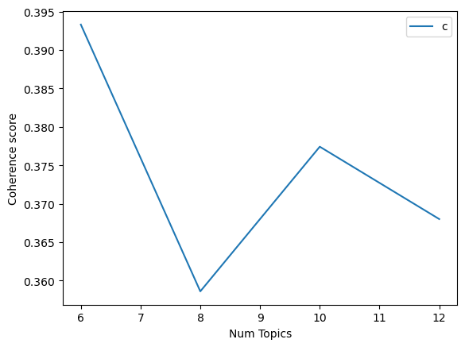

```python
import time

def compute_coherence_values(dictionary, corpus, texts, limit, start=2, step=3):
    coherence_values = []
    model_list = []
    for num_topics in range(start, limit, step):
        start_time = time.time()
        print(f"Training LDA model with {num_topics} topics...")

        model = LdaModel(corpus=corpus, id2word=dictionary, num_topics=num_topics, passes=20, random_state=100)
        model_list.append(model)

        coherencemodel = CoherenceModel(model=model, texts=texts, dictionary=dictionary, coherence='c_v')
        coherence = coherencemodel.get_coherence()
        coherence_values.append(coherence)

        end_time = time.time()
        print(f"Model with {num_topics} topics complete. Coherence Score: {coherence:.4f}. Time taken: {end_time - start_time:.2f}s\n")

    return model_list, coherence_values

model_list, coherence_values = compute_coherence_values(dictionary=dictionary, corpus=corpus, texts=processed_data, start=6, limit=14, step=2)

limit=14; start=6; step=2;
x = range(start, limit, step)
plt.plot(x, coherence_values)
plt.xlabel("Num Topics")
plt.ylabel("Coherence score")
plt.legend(("coherence_values"), loc='best')
plt.show()
```

```python
optimal_model = model_list[0]  # Since the model with 6 topics had the highest coherence score


document_topics = [optimal_model.get_document_topics(bow) for bow in corpus]

topic_counts = [0] * optimal_model.num_topics
for doc_topics in document_topics:
    dominant_topic = max(doc_topics, key=lambda x: x[1])[0]
    topic_counts[dominant_topic] += 1

top_5_topics = sorted(range(len(topic_counts)), key=lambda k: topic_counts[k], reverse=True)[:5]
for idx, topic in enumerate(top_5_topics):
    print(f"Topic {idx + 1}:")
    print(optimal_model.print_topic(topic))
```

```
Topic 1:
0.015*"trump" + 0.008*"people" + 0.006*"clinton" + 0.006*"would" + 0.005*"one" + 0.005*"said" + 0.005*"hillary" + 0.004*"party" + 0.004*"white" + 0.004*"election"
Topic 2:
0.009*"syria" + 0.007*"russia" + 0.007*"war" + 0.006*"force" + 0.006*"said" + 0.006*"syrian" + 0.005*"government" + 0.005*"saudi" + 0.005*"military" + 0.005*"russian"
Topic 3:
0.010*"trump" + 0.007*"black" + 0.006*"people" + 0.006*"said" + 0.005*"state" + 0.005*"obama" + 0.005*"election" + 0.005*"police" + 0.005*"one" + 0.004*"white"
Topic 4:
0.022*"clinton" + 0.009*"email" + 0.007*"hillary" + 0.007*"fbi" + 0.005*"new" + 0.005*"state" + 0.005*"campaign" + 0.004*"one" + 0.004*"foundation" + 0.004*"said"
Topic 5:
0.006*"american" + 0.006*"war" + 0.005*"black" + 0.005*"state" + 0.004*"party" + 0.004*"people" + 0.004*"one" + 0.004*"world" + 0.004*"would" + 0.003*"time"
```

```python
optimal_model.save('lda_model_6_topics.model')
```

```python
unlabeled = [
    "Aliens landed in Area 51 and collaborated with the government to create advanced technology.",
    "The Bermuda Triangle is actually a portal to another dimension, and that's why ships and planes disappear.",
    "Vaccines were invented as a means to control the global population."
]

processed_unlabeled = preprocess_text(unlabeled)

unlabeled_corpus = [dictionary.doc2bow(text) for text in processed_unlabeled]

best_model = model_list[coherence_values.index(max(coherence_values))]

for i, topics in enumerate(unlabeled_corpus):
    print(f"Fake news example {i+1}:")
    for index, score in sorted(best_model[topics], key=lambda tup: -1*tup[1]):
        print(f"Topic: {index} Score: {score:.4f}")
    print("\n")
```

```
Fake news example 1:
Topic: 2 Score: 0.4211
Topic: 0 Score: 0.2923
Topic: 4 Score: 0.2304
Topic: 1 Score: 0.0188
Topic: 3 Score: 0.0188
Topic: 5 Score: 0.0187


Fake news example 2:
Topic: 4 Score: 0.7534
Topic: 1 Score: 0.1710
Topic: 5 Score: 0.0190
Topic: 3 Score: 0.0189
Topic: 2 Score: 0.0189
Topic: 0 Score: 0.0188


Fake news example 3:
Topic: 1 Score: 0.8797
Topic: 2 Score: 0.0242
Topic: 0 Score: 0.0241
Topic: 4 Score: 0.0241
Topic: 3 Score: 0.0240
Topic: 5 Score: 0.0239
```

## Section 6: Business Intelligence

```python
most_prevalent_topic = topic_counts.index(max(topic_counts))
print(f"The most prevalent topic is Topic {most_prevalent_topic + 1}")
```

```
The most prevalent topic is Topic 2
```

```python
def get_most_representative_docs(document_topics):
    most_representative_docs = [-1] * optimal_model.num_topics
    max_contributions = [0] * optimal_model.num_topics

    for doc_id, doc_topics in enumerate(document_topics):
        for topic_id, contribution in doc_topics:
            if contribution > max_contributions[topic_id]:
                max_contributions[topic_id] = contribution
                most_representative_docs[topic_id] = doc_id

    return most_representative_docs

most_representative_docs = get_most_representative_docs(document_topics)
for idx, doc_id in enumerate(most_representative_docs):
    print(f"Most representative document for Topic {idx + 1} is Document {doc_id + 1}")
```

```
Most representative document for Topic 1 is Document 60
Most representative document for Topic 2 is Document 572
Most representative document for Topic 3 is Document 438
Most representative document for Topic 4 is Document 595
Most representative document for Topic 5 is Document 1304
Most representative document for Topic 6 is Document 642
```

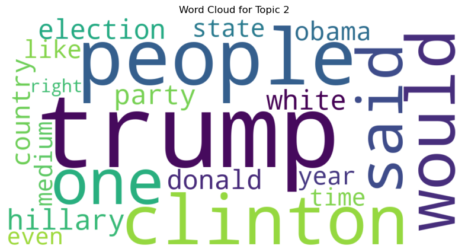

```python
from wordcloud import WordCloud
import matplotlib.pyplot as plt

def generate_wordcloud_for_topic(topic_number):
    topic_words = dict(optimal_model.show_topic(topic_number, topn=20))

    wc = WordCloud(background_color="white", width=1000, height=500, max_words=20).generate_from_frequencies(topic_words)

    plt.figure(figsize=(10,5))
    plt.imshow(wc, interpolation='bilinear')
    plt.axis('off')
    plt.title(f"Word Cloud for Topic {topic_number + 1}")
    plt.show()

generate_wordcloud_for_topic(most_prevalent_topic)
```

## Section 7: Story Telling

> a.) Interpretations of the overall results: Upon applying topic modeling techniques, I found distinct themses that emerge from the news articles in our dataset. Some topics centered around political figures such as Trump and Clinton, while others dove into topics in the world of geopolitics such as Syria, Russia, and the military. The fake news examples were run through the model, and they were associated to different topics. The story about area 51 aliens for instance related to topics discussing governments and global situations, white the Bermuda triangle had a strong association with world events, and possible conspiracies.

> b.) Technical Implications for my Client:

> > 1.) Model Maintenance: Topic models may need regular updating as new content and themes emerge in the news.

> > 2.) Scalability: If the client plans to analyze larger datasets, the current architecture might need to be revisited for performance optimizations.

> > 3.) Further Analysis: This model can be integrated with other NLP processes like sentiment analysis to gauge the sentiment around each topic.

> c.) Managerial Implications:

> > 1.) Content Strategy: Understanding prevalent topics can help content creators or marketers tailor their messages to resonate with current events or steer clear of controversial subjects.

> > 2.) Fact-checking and Validation: Managers can set up teams to validate news pieces that are associated with topics known to be common with fake news, ensuring the credibility of the information they disseminate or act upon.

> > 3.) Educating the Audience: Awareness campaigns can be run to educate the audience about prevalent fake news themes, making them more discerning readers.

> d.)To combat the proliferation of fake news online, it's essential to employ a combination of machine learning models for automatic detection and fact-checking APIs from reputable organizations. Additionally, scrutinizing the credibility of news sources, analyzing content sentiment, studying sharing patterns, and leveraging user reports can significantly enhance the accuracy of identifying deceptive content.